# Identifying opportunities in Jumpman23 delivery activity in the NYC market

### How does order volume change by hour of the day?

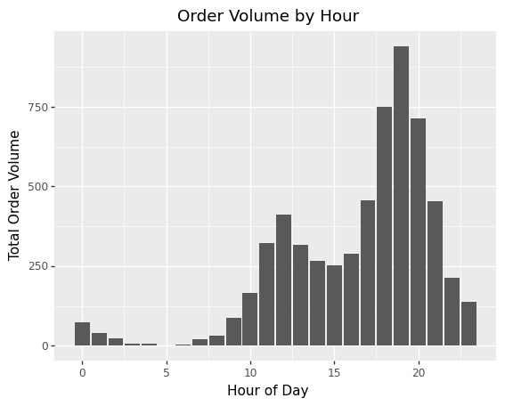

```python
(
    ggplot(jump23) +
    aes(x = 'delivery_start_hour') +
    geom_bar() +
    labs(title = 'Order Volume by Hour', x = 'Hour of Day', y = 'Total Order Volume')

)
```

**Orders by hour are strongly left-skewed, with most orders occuring in the early evening hours.**

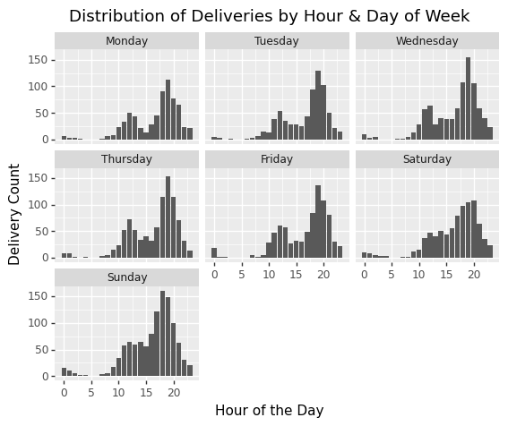

```python
(
    ggplot(jump23) +
    aes(x = 'delivery_start_hour') +
    geom_bar() +
    facet_wrap('delivery_DOW_name') +
    labs(title = 'Distribution of Deliveries by Hour & Day of Week', x = 'Hour of the Day', y = 'Delivery Count')
)
```

**This trend appears to hold across all days of the week. Peak orders on Sunday occur about an hour earlier than they do the rest of the week.**

### Begin Maps

```python
pickup_geo = jump23.loc[:,'pickup_lat':'pickup_lon']
dropoff_geo = jump23.loc[:, 'dropoff_lat':'dropoff_lon']
```

```python
pickup_geo.agg(max)
```

```
pickup_lat    40.818082
pickup_lon   -73.920980
dtype: float64
```

```python
pickup_geo.agg(min)
```

```
pickup_lat    40.665611
pickup_lon   -74.015837
dtype: float64
```

```python
# nyc_geo = 'C:\\Users\\alex.talbott\\Desktop\\Alex Talbott Stuff\\Python\\Datasets\\GEO files\\2010_nyc_census_blocks.geojson'
```

```python
map_nyc_pickup = folium.Map(location=[pickup_geo.pickup_lat.mean(), pickup_geo.pickup_lon.mean()], tiles = 'stamentoner', zoom_start = 11.5)
map_nyc_dropoff = folium.Map(location=[dropoff_geo.dropoff_lat.mean(), dropoff_geo.dropoff_lon.mean()], tiles = 'stamentoner', zoom_start = 11.5)
```

```python
map_heat_pickup = map_nyc_pickup.add_children(plugins.HeatMap(pickup_geo, radius = 12))
map_heat_pickup
```

[interactive chart not shown]

**We can tell quite a lot about where in-demand merchants are located from the above heat map of pickup locations. It appears that the highest concentration of pickups for the aggregated time period of October 2014 occurred in downtown manhattan. Compared to downtown Manhattan, merchant pickup activity lessens in midtown, with pockets of high vendor pickup activity in the Upper West Side and Upper East Side neighborhoods. There is also a small pocket of activity in the Dumbo neighborhood.**

*Let's compare to a heatmap of the dropoff locations.*

```python
map_heat_dropoff = map_nyc_dropoff.add_children(plugins.HeatMap(dropoff_geo, radius = 12))
map_heat_dropoff
```

[interactive chart not shown]

**The heat map of dropoffs shares some similarities with the heap map of pickup locations, but also contains some marked differences. While downtown remains a hot spot, dropoffs appear to be concentrated towards the center of downtown in between 2nd Avenue and 6th Avenue, whereas pickup locations had the highested concentration nearer to the perimeter of downtown. One hypothesis is that workplaces and apartments are more highly concentrated downtown, whereas restaurants are more spread out.**

**We can see that there is a higher demand activity than merchant activity in the east side of manhattan, and the west side is a hotspot for pickups but not for dropoffs. Quick research indicates that there is a stronger offering of walkable restaurants on the west side than in the east side, which could account for the discrepancy.**

## In Summary:

1. Bike deliveries appear to be more time-efficient than car deliveries. We should consider transitioning our car delivery jumpmen entirely to bikes, motorcycles and scooters when possible (i.e. the order is not too big, and the weather permits).
2. We identified data integrity issues related missing item data. We also determined we should examine how we are recording merchant arrival times. We operated under the assumption that these missing values were distributed simiarly to the other 80% of the datset, but if this is not the case it could have an impact on the accuracy of the above analysis.
3. Given the high demand for deliveries on Sundays, we should consider increased marketing spend on Sunday in the afternoon and early evening to capitalize on higher demand. We should pursue an aggressive marketing strategy downtown to capitalize on the high demand in that area.

## Next Steps

Next steps to pursue would include:

1. Layering census block data into the heat maps and dataset to analyze pickup and dropoff activity by specific NYC regions more thoroughly.
2. Supplementing the dataset with demographic and weather information, including income estimates by census tract. This would allow us to compare delivery volume with clientele discretionary spending and visualize how delivery duration changes with different weather scenarios, perhaps leading to different vehicle type decisions.
3. Add revenue data to dataset, in order to analyze and optimize towards higher-value delivery transactions.